# PCA Demo

## Example 2: performing PCA on materials science data and using that for inference

First, we load in our dataset. This uses a format call HDF5, which is nice for storing large amounts of spatially-varying (or otherwise complex) data. This set in particular contains a set of 1000 synethic "material microstructures", which are 2D images with value either "0" or "1" at every pixel. These numbers correspond to the thermal and mechanical material properties of each pixel.

A classic question in computational materials science is the effect of microstructure (how the black and white pixel are arranged) on the response and effective properties when we apply loads to the material. We can compute these properties by simulating each microstructure, but those simulations can get expensive. Can we use data science to estimate properties without running a full simulation?

### Data loading

First, we load the HDF5 file and pull out some important quantities: the microstructures themselves, effective thermal properties (called "thermal_prop", and the "class" of each structure (an integer between 0 and 7). We also set up some helper functions that we'll use later.

```python
plt.clf();
%matplotlib inline
f = File('materials_data.h5')

# homogenized properties: N vector
thermal_props = f['responses'][:]
# (N x 256 x 256), all entries zero or one
micros = f['micros'][:]
# (N x 1) storing an integer 0-7 for class
classes = f['classes'][:];
```

```python
# Helper functions here
def compute_autocorr(m):
    # compute two-point spatial correlations of the first phase of a batch of microstructures
    # assumes input is shape (batch, x, y)
    # uses forward normalization to simplify scaling
    m_ft = np.fft.fftn(m, axes=(-2,-1), norm='forward')
    # multiplication in Fourier space is same as convolution in real space
    s_ft = m_ft.conj() * m_ft

    s = np.fft.ifftn(s_ft, axes=(-2, -1), s=m.shape[-2:], norm='forward')

    return s.real

def plot_slice(field, cmap='gray', shift=False, ax=None, labels=True, crop=None, cb = False):

    if shift:
        field = np.fft.fftshift(field, axes=(-2, -1))

    if crop:
        # crop out to central # pixels (crop x crop) in size
        nx, ny = field.shape
        # half-length
        hl = crop // 2
        # get starting pixels in x and y
        sx = nx//2 - hl
        sy = ny//2 - hl
        field = field[sx:sx+crop, sy:sy+crop]

    if ax is None:
        fig, ax = plt.subplots(num=" ")
        cb = True

    im=ax.imshow(field.T, origin='lower', cmap=cmap)
    if cb:
        divider = make_axes_locatable(ax)
        cax = divider.append_axes('right', size='5%', pad=0.05)
        cbar = plt.gcf().colorbar(im, cax = cax)
        cbar.ax.tick_params(labelsize=10)
    if labels:
        ax.set_xlabel("x"), ax.set_ylabel("y")
    else:
        ax.set_xticks([])
        ax.set_yticks([])
```

## Visualizations

First, let's visualize some of our data. We'll plot a selection of microstructures (only the Z=0 slice for easier visualization).

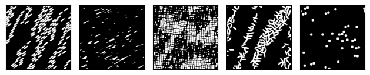

```python
fig, axes = plt.subplots(1, 5, figsize=(10, 2), num=" ")

# plot a subsample of entries roughly spaced to get different classes each time
inds_plot = np.arange(5) * 100 + 5
# lazy one-liner to plot lots of things at once
[plot_slice(micros[inds_plot[i]], ax=axes[i], labels=False) for i in range(5)]
fig.tight_layout()
plt.show()
```

These structures are periodic; that is, when you leave one side you just wrap around to the other. As a result, we can make a bunch of equivalent structures just by moving our origin point. One easy way to resolve this is by taking what's called a **spatial autocorrelation**. The exact details aren't too important -- basically, the autocorrelation averages all possible origins without throwing away too much information, giving us a *fingerprint* of the microstructure. The helper function for this is above. For fun, we can visualize the effect of the autocorrelation procedure on the structures above. Since a lot of the detail is stored near the center, we also plot just the central 32x32 pixels as well.

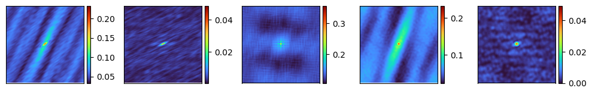

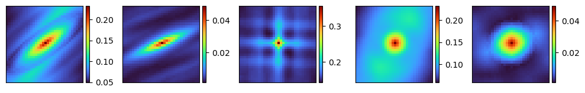

```python
# compute autocorrelations for each structure, might take a second or two
autocorrs = compute_autocorr(micros)

fig, axes = plt.subplots(1, 5, figsize=(10, 2), num=" ")
# lazy one-liner to plot lots of things at once
[plot_slice(autocorrs[inds_plot[i]], ax=axes[i], labels=False, shift=True, cmap="turbo", cb=True) for i in range(5)]
fig.tight_layout()
plt.show()

fig, axes = plt.subplots(1, 5, figsize=(10, 2), num=" ")
# lazy one-liner to plot lots of things at once
[plot_slice(autocorrs[inds_plot[i]], ax=axes[i], labels=False, shift=True, cmap="turbo", cb=True, crop=32) for i in range(5)]
fig.tight_layout()
plt.show()
```

## Dimensionality reduction

Now we want to use the autocorrelations to perform inference, but they're still very high-dimensional (256x256 = 65536 pixels)! In order to simplify these we first center and flatten them into a set of vectors of length 65536, then perform PCA on those vectors.

```python
def preprocess(X):
    # assume X is an array of size (batch, x, y, z) autocorrelations. Centers and flattens them appropriately
    X = X.reshape(X.shape[0], -1)
    X = X - X.mean(0, keepdims=True)
    return X

X = preprocess(autocorrs)
U, s, Vt = svd(X, full_matrices=False)

print(f"X shape is {X.shape}")
print(f"U shape is {U.shape}")
print(f"s shape is {s.shape}")
print(f"V^T shape is {Vt.shape}")
```

```
X shape is (1000, 65536)
U shape is (1000, 1000)
s shape is (1000,)
V^T shape is (1000, 65536)
```

### Visualizing the PC vectors

We can look at which features PCA picks up by reshaping and plotting our *right singular vectors* -- the columns of $V$ above (or rows of $V^T$). The "importance" of each PC vector is captured by the *singular values*: entries of the $s$ vector (or diagonal entries of the matrix version $S$).

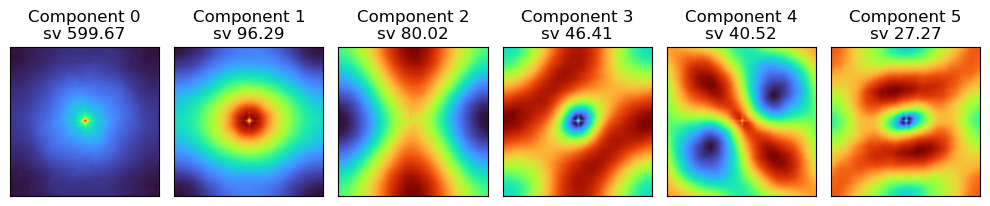

```python
fig, axes = plt.subplots(1, 6, figsize=(10, 3), num=" ")
# lazy one-liner to plot lots of things at once
for i in range(6):
    sing_vec_im = Vt[i].reshape(256, 256)
    plot_slice(sing_vec_im, ax=axes[i], labels=False, shift=True, cmap="turbo")
    axes[i].set_title(f"Component {i}\nsv {s[i]:.2f}")

fig.tight_layout()
plt.show()
```

Woah! That first component is **much** more important than the others. In fact, we can compute how much information (e.g. what percent of total variance in $X$ is captured by each vector. This is done by summing the squared singular values to get the total variance, and then dividing each (squared) value by that sum. This can be summarized in what's called a *scree plot*. Since we know the first component is so important, we'll skip that one in the scree plot so we can see the effect of adding more components after that one. Another way to visualize this is the cumulative variance captured by the first $k$ components.

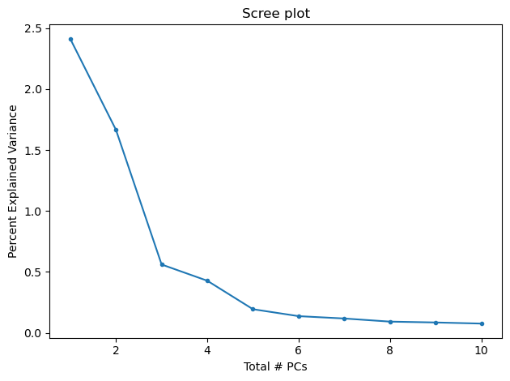

```python
s2 = s**2
var_exp = s2 / s2.sum()

plt.figure(num=" ")
plt.plot(np.arange(1, 11), 100 * var_exp[1:11], marker=".")
plt.title("Scree plot")
plt.xlabel("Total # PCs")
plt.ylabel("Percent Explained Variance");
plt.tight_layout()
```

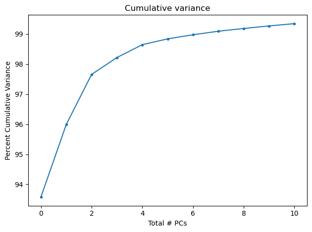

```python
plt.figure(num=" ")
plt.plot(100 * np.cumsum(var_exp[:11]), marker=".")
plt.title("Cumulative variance")
plt.xlabel("Total # PCs")
plt.ylabel("Percent Cumulative Variance");
plt.tight_layout()
```

It looks like the the first component is focusing heavily on the central pixel. In fact, this pixel captures the *volume fraction*: what proportion of the image is white pixels (ignoring any spatial patterns)? We can see this by plotting the first PC score against volume fraction

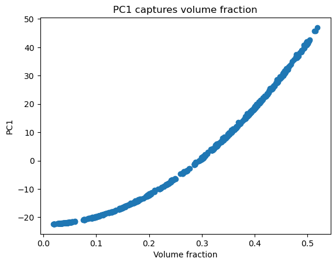

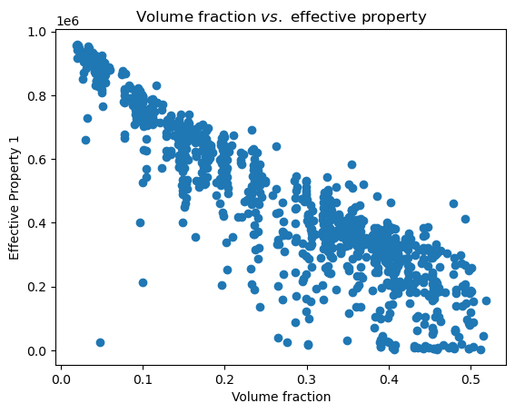

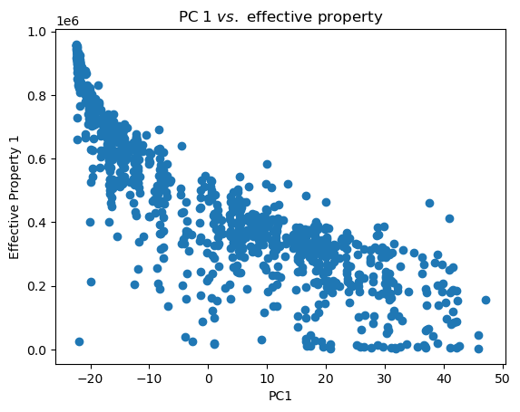

```python
# average over spatial dims to get total # white pixels
vfs = micros.mean((-2, -1))

# now get principle components (columns of U * S)
pcs = U @ np.diag(s)
pc_1 = pcs[:, 0]

plt.figure(num=" ")
plt.scatter(vfs, pc_1)
plt.xlabel("Volume fraction"), plt.ylabel("PC1"), plt.title("PC1 captures volume fraction")
plt.show()

plt.figure(num=" ")
plt.scatter(vfs, thermal_props[:, 0])
plt.xlabel("Volume fraction"), plt.ylabel("Effective Property 1"), plt.title("Volume fraction $vs.$ effective property")
plt.show()

plt.figure(num=" ")
plt.scatter(pc_1, thermal_props[:, 0])
plt.xlabel("PC1"), plt.ylabel("Effective Property 1"), plt.title("PC 1 $vs.$ effective property")
plt.show()
```

## Reconstructions

How do we reconstruct the compressed samples? Simply truncate to the top $k$ PC-scores, then use the top $k$ principal directions to pull back into the large basis:

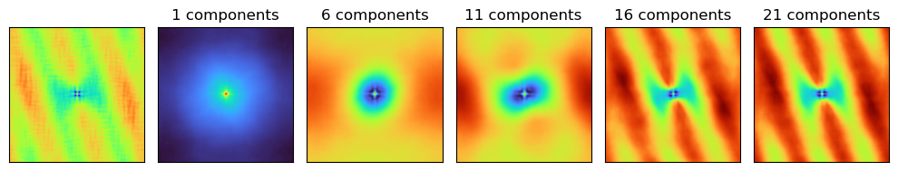

```python
fig, axes = plt.subplots(1, 6, figsize=(10, 3), num=" ")
# lazy one-liner to plot lots of things at once
plot_slice((pcs[255, :] @ Vt[:]).reshape(256, 256), ax=axes[0], labels=False, shift=True, cmap="turbo")
axes[i].set_title(f"original")


for i in range(1,6):
    num_pcs = 1 + 5 * (i-1)
    recon = (pcs[255, :num_pcs] @ Vt[:num_pcs]).reshape(256, 256)
    plot_slice(recon, ax=axes[i], labels=False, shift=True, cmap="turbo")
    axes[i].set_title(f"{num_pcs} components")

fig.tight_layout()
plt.show()
```

```python
print(Vt[:i, :].shape, pcs[:, :i].shape)
print((pcs[:, :i] @ Vt[:i]).shape)
```

```
(5, 65536) (1000, 5)
(1000, 65536)
```

## Comparing to SKLearn

We can double-check our implementation by comparing it to scikit-learn. We see that the singular values are exactly the same, and the principle components are the same up to sign flips

```python
from sklearn.decomposition import PCA

X = preprocess(autocorrs)

pca = PCA()
pca.fit(X);

x_trans = pca.transform(X)
```

```
[-21.81620572 -20.27918868 -14.25201987 -21.84560725 -22.18990225] [-21.81620572 -20.27918868 -14.25201987 -21.84560725 -22.18990225]
```

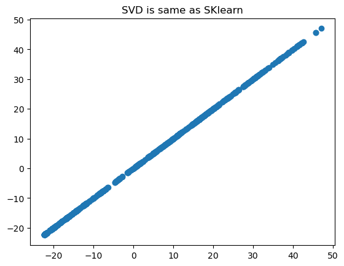

```python
# plot PC1 computed with each method against each other for comparison
x_trans = pca.transform(X)

plt.scatter(x_trans[:, 0], pcs[:, 0])
plt.title("SVD is same as SKlearn");
print(x_trans[:5, 0], pcs[:5, 0])
```

```
Sklearn SVs: [599.67148098  96.288391    80.01712221  46.41069382  40.52360232]
Custom SVs: [599.67148098  96.288391    80.01712221  46.41069382  40.52360232]
```

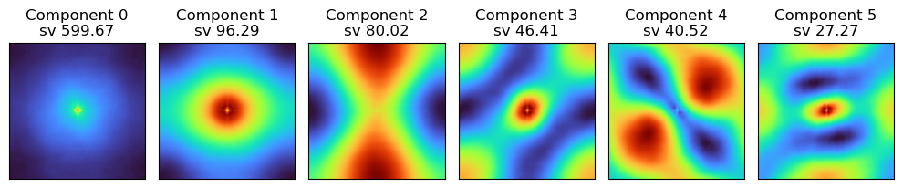

```python
print("Sklearn SVs:", pca.singular_values_[:5])
print("Custom SVs:", s[:5])

fig, axes = plt.subplots(1, 6, figsize=(10, 3), num=" ")

for i in range(6):
    sing_vec_im = pca.components_[i].reshape(256, 256)
    plot_slice(sing_vec_im, ax=axes[i], labels=False, shift=True, cmap="turbo")
    axes[i].set_title(f"Component {i}\nsv {s[i]:.2f}")
plt.tight_layout()
plt.show()
```

## Visualizing the latent space

We can explore the latent space produced by PCA by plotting the low-dimensional representations (PC scores) against each other. Here we plot the first two PCs (using one-based indexing) against several other components. Each point is colored by the first thermal property -- it looks like there's some clear patterns in the first few dimensions!

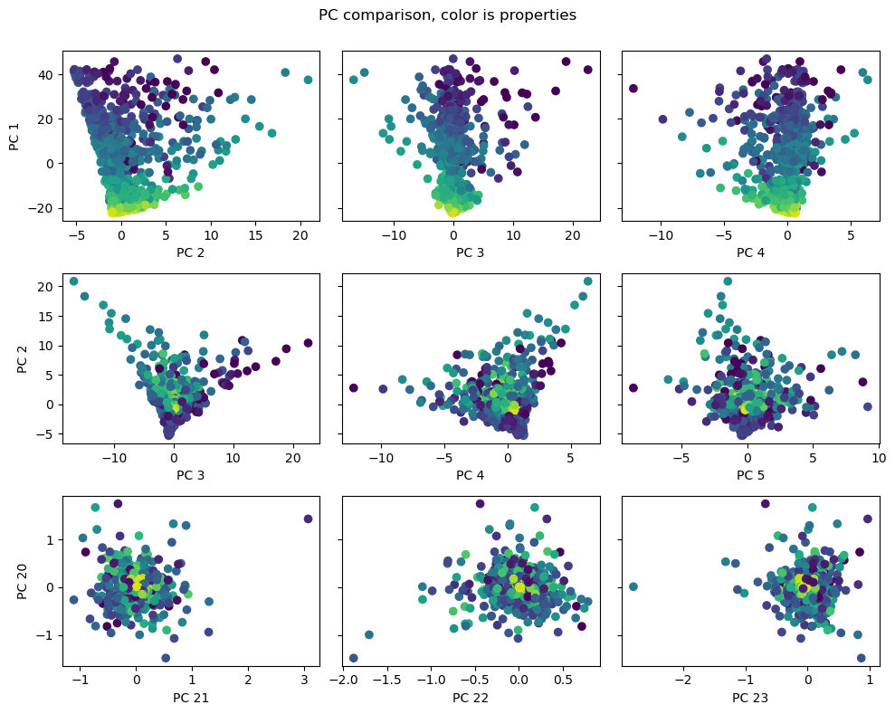

```python
fig, ax = plt.subplots(3, 3, num = " ", figsize=(10, 8), sharey="row")
for i in range(3):
    ax[0, i].scatter(pcs[:, i+1], pcs[:, 0], c=thermal_props[:, 0])
    ax[0, i].set_xlabel(f"PC {i + 2}")
    #ax[i].set(adjustable='box-forced', aspect='equal')
for i in range(3):
    ax[1, i].scatter(pcs[:, i+2], pcs[:, 1], c=thermal_props[:, 0] )
    ax[1, i].set_xlabel(f"PC {i + 3}")
    #ax[i].set(adjustable='box-forced', aspect='equal')
for i in range(3):
    ax[2, i].scatter(pcs[:, i+20], pcs[:, 19], c=thermal_props[:, 0] )
    ax[2, i].set_xlabel(f"PC {i + 21}")
    #ax[i].set(adjustable='box-forced', aspect='equal')
ax[0,0].set_ylabel(f"PC {1}")
ax[1,0].set_ylabel(f"PC {2}")
ax[2,0].set_ylabel(f"PC {20}")
plt.suptitle("PC comparison, color is properties\n")

plt.tight_layout()
plt.show()
```

Note that this dataset was actually designed to *cover the PC space equally for all classes*; that is, we shouldn't expect PCA to separate the classes. We reproduce that first plot above, but this time using class as the color:

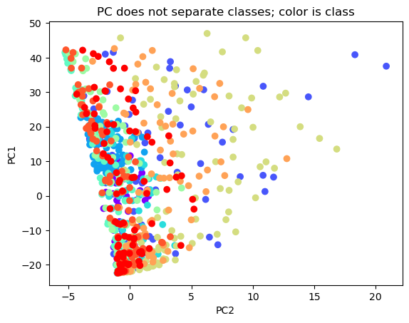

```python
plt.scatter(pcs[:, 1], pcs[:, 0], c=classes / 7., cmap="rainbow")
plt.title("PC does not separate classes; color is class")
plt.xlabel("PC2"), plt.ylabel("PC1")
plt.show()
```

## Doing inference

Now let's try and use this dimensionality reduction for inference. To keep things simple we'll use Bayesian Linear Regression via Scikit-learn, with default settings. We also normalize our outputs $y$ to keep things scaled nicely.

```python
num_train = 500
num_total = f['micros'].shape[0]

# randomly select training data (ignoring class order
inds = np.arange(num_total)
np.random.shuffle(inds)
# get training indices, them sort them for hdf5 to play nice
inds_train = sorted(inds[:num_train])
inds_test = sorted(inds[num_train:])

# homogenized properties: N vector
y_train = thermal_props[inds_train, 0]
y_test = thermal_props[inds_test, 0]
# (N x 256 x 256), all entries zero or one
micros_train = micros[inds_train]
micros_test = micros[inds_test]
```

```python
# (N x 256 x 256), all entries zero or one
micros_train = micros[inds_train]
micros_test = micros[inds_test]

Xbig_train = preprocess(compute_autocorr(micros_train))
Xbig_test = preprocess(compute_autocorr(micros_test))

print(Xbig_train.shape)

# get PC fit on **training set only**
U_, s_, Vh_ = svd(Xbig_train, full_matrices=False)
```

```
(500, 65536)
```

```python
# homogenized properties: N vector
y_train = thermal_props[inds_train, 0]
y_test = thermal_props[inds_test, 0]

X_train_all = U_ @ np.diag(s_)
# apply PCA directly onto test data
X_test_all = Xbig_test @ Vh_.T

num_pcs = 1

# now truncate off all but first k PCs
X_train = X_train_all[:, :num_pcs]
X_test = X_test_all[:, :num_pcs]


y_norm_mean = y_train.mean()
y_norm_std = y_train.std()
y_train = (y_train - y_norm_mean) / y_norm_std
y_test = (y_test - y_norm_mean) / y_norm_std
```

```python
import sklearn.linear_model
blr = sklearn.linear_model.BayesianRidge()

blr.fit(X_train, y_train);
```

Cool. Now that we've fit a model, how should we evaluate it? Let's use a mean-absolute error in (normalized) property, and scale it to get a percent error. We can also plot the predicted property vs true property. Ideally, these should be the same, in which case we'd expect a straight line. Since the true model almost certainly isn't linear, we shouldn't expect to get it perfect this time around.

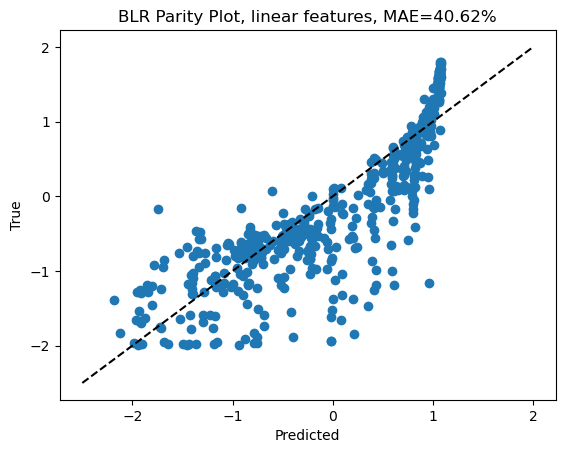

```python
ymean, ystd = blr.predict(X_test, return_std=True)

MAE = abs(ymean - y_test).mean()

plt.figure()
plt.scatter(ymean, y_test)
plt.plot((-2.5, 2), (-2.5, 2), "k--", label="Ideal")
plt.xlabel("Predicted"), plt.ylabel("True"), plt.title(f"BLR Parity Plot, linear features, MAE={100*MAE:.2f}%");
```

```python
print(blr.coef_)
```

```
[-0.04708821]
```

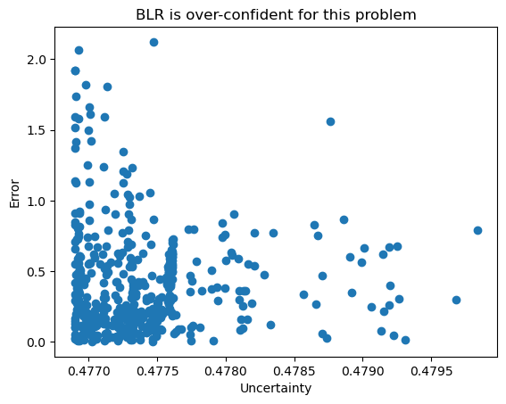

```python
plt.figure()
plt.scatter(ystd, abs(ymean - y_test))
plt.xlabel("Uncertainty"), plt.ylabel("Error")
plt.title("BLR is over-confident for this problem");
```

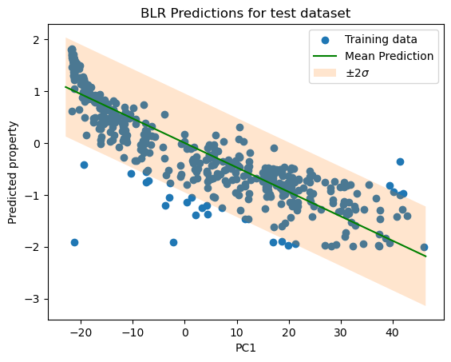

```python
# sort testing x locations
inds_sort = np.argsort(X_test[:, 0])


plt.figure(num=" ")
plt.scatter(X_train[:, 0], y_train, label="Training data")
plt.plot(X_test[inds_sort, 0], ymean[inds_sort], "g-", label="Mean Prediction")
plt.fill_between(X_test[inds_sort, 0], (ymean - 2*ystd)[inds_sort], (ymean + 2*ystd)[inds_sort], alpha=0.2, label=r"$\pm 2 \sigma$")
plt.xlabel("PC1"), plt.ylabel("Predicted property"), plt.title("BLR Predictions for test dataset")
plt.legend();
```

## BLR, 10 PCs

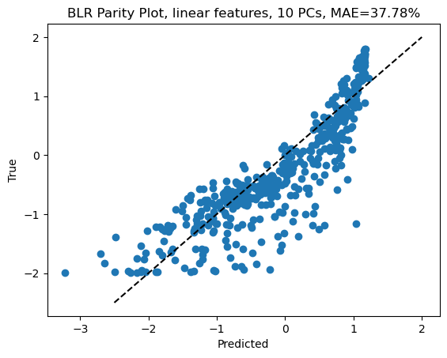

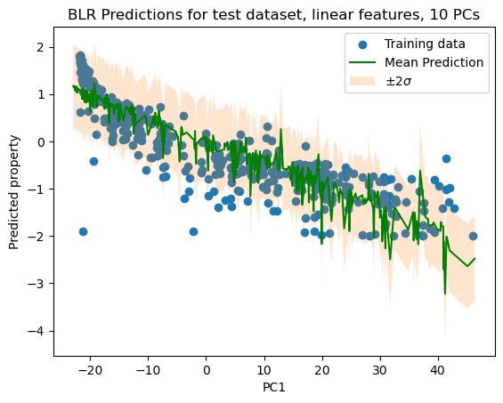

```python
XX_train = X_train_all[:, :10]
XX_test = X_test_all[:, :10]

blr.fit(XX_train, y_train);
ymean, ystd = blr.predict(XX_test, return_std=True)

MAE = abs(ymean - y_test).mean()

plt.figure()
plt.scatter(ymean, y_test)
plt.plot((-2.5, 2), (-2.5, 2), "k--", label="Ideal")
plt.xlabel("Predicted"), plt.ylabel("True"), plt.title(f"BLR Parity Plot, linear features, 10 PCs, MAE={100*MAE:.2f}%");


# sort testing x locations
inds_sort = np.argsort(X_test[:, 0])


plt.figure(num=" ")
plt.scatter(X_train[:, 0], y_train, label="Training data")
plt.plot(X_test[inds_sort, 0], ymean[inds_sort], "g-", label="Mean Prediction")
plt.fill_between(X_test[inds_sort, 0], (ymean - 2*ystd)[inds_sort], (ymean + 2*ystd)[inds_sort], alpha=0.2, label=r"$\pm 2 \sigma$")
plt.xlabel("PC1"), plt.ylabel("Predicted property"), plt.title("BLR Predictions for test dataset, linear features, 10 PCs")
plt.legend();
```

## BLR, 1 PC but polynomial features

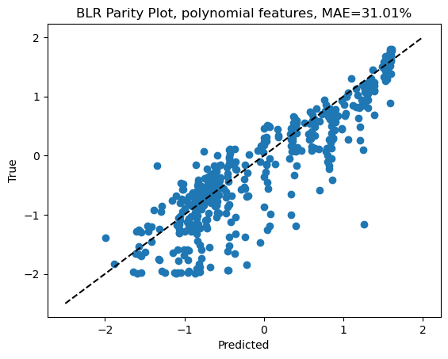

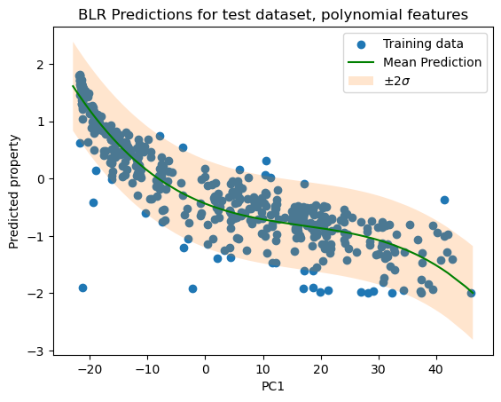

```python
XX_train = np.concatenate((X_train, X_train**2, X_train**3), -1)
XX_test = np.concatenate((X_test, X_test**2, X_test**3), -1)

blr.fit(XX_train, y_train);
ymean, ystd = blr.predict(XX_test, return_std=True)

MAE = abs(ymean - y_test).mean()

plt.figure()
plt.scatter(ymean, y_test)
plt.plot((-2.5, 2), (-2.5, 2), "k--", label="Ideal")
plt.xlabel("Predicted"), plt.ylabel("True"), plt.title(f"BLR Parity Plot, polynomial features, MAE={100*MAE:.2f}%");


# sort testing x locations
inds_sort = np.argsort(X_test[:, 0])


plt.figure(num=" ")
plt.scatter(X_train[:, 0], y_train, label="Training data")
plt.plot(X_test[inds_sort, 0], ymean[inds_sort], "g-", label="Mean Prediction")
plt.fill_between(X_test[inds_sort, 0], (ymean - 2*ystd)[inds_sort], (ymean + 2*ystd)[inds_sort], alpha=0.2, label=r"$\pm 2 \sigma$")
plt.xlabel("PC1"), plt.ylabel("Predicted property"), plt.title("BLR Predictions for test dataset, polynomial features")
plt.legend();
```

Just for fun, let's try a more powerful model: Gaussian Process Regression. We won't do anything fancy for now.

```python
import sklearn.gaussian_process
from sklearn.gaussian_process.kernels import RBF, ConstantKernel, WhiteKernel
gpr = sklearn.gaussian_process.GaussianProcessRegressor(kernel = RBF() + WhiteKernel(), alpha = 1e-1)

gpr.fit(X_train, y_train);
```

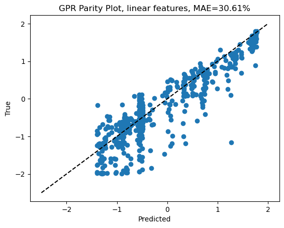

```python
ymean, ystd = gpr.predict(X_test, return_std=True)
MAE = abs(ymean - y_test).mean()

plt.figure()
plt.scatter(ymean, y_test)
plt.plot((-2.5, 2), (-2.5, 2), "k--", label="Ideal")
plt.xlabel("Predicted"), plt.ylabel("True"), plt.title(f"GPR Parity Plot, linear features, MAE={100*MAE:.2f}%");
```

```python
print(ymean.min(), ymean.max())
print(y_test.min(), y_test.max())
gpr.get_params()
gpr.kernel_
```

```
-1.394324592178628 1.7829586317541875
-1.9970895678628526 1.8044991207421746
```

```
RBF(length_scale=8.82) + WhiteKernel(noise_level=0.036)
```

It looks like GPR is doing an ok job -- better than BLR, and surprisingly good how little data we're giving it.

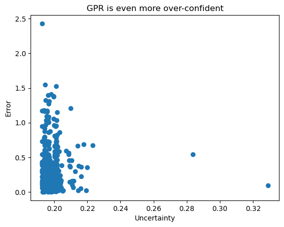

```python
plt.figure()
plt.scatter(ystd, abs(ymean - y_test))
plt.xlabel("Uncertainty"), plt.ylabel("Error")
plt.title("GPR is even more over-confident");
```

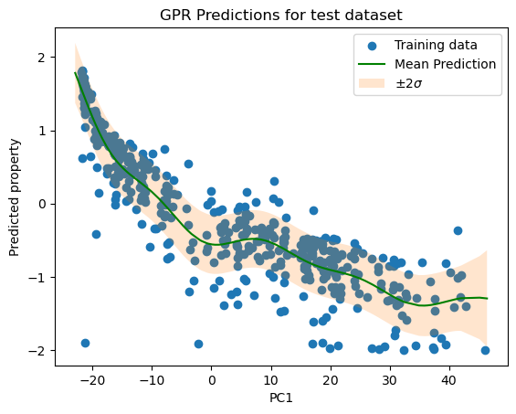

```python
# sort testing x locations
inds_sort = np.argsort(X_test[:, 0])


plt.figure(num=" ")
plt.scatter(X_train[:, 0], y_train, label="Training data")
plt.plot(X_test[inds_sort, 0], ymean[inds_sort], "g-", label="Mean Prediction")
plt.fill_between(X_test[inds_sort, 0], (ymean - 2*ystd)[inds_sort], (ymean + 2*ystd)[inds_sort], alpha=0.2, label=r"$\pm 2 \sigma$")
plt.xlabel("PC1"), plt.ylabel("Predicted property"), plt.title("GPR Predictions for test dataset")
plt.legend();
```

## Wrapup

PCA is a very powerful tool for dimensionality reduction, but it relies on very strong assumptions (linear, Gaussian). It's a great first step and way to explore your dataset since it won't mess too much with internal patterns in the data, but it may not give the best latent representation for analysis or inference.

Note that adding more features or PCs isn't always a good thing, and that simpler models can outperform more complex ones. The only way to know is to test things and see what works.

## More things you can try:

- Use more than one PC score with regression (more accurate, but trickier to tune!)
- Try tuning hyperparameters to see if you can get a better fit
- Cross-validation rather than 50-50 split
- Nonlinear dimension reduction
- Test sensitivity to error (e.g. flipped pixels in inputs)